# Recapturing Planes

Lee & Wagenmakers Part II. 5.6, p73

cn

2024-03-20

```r
set.seed(12345)

if (!require("pacman", quietly = TRUE)) install.packages("pacman")
pacman::p_load(cowplot, R2jags)
pacman::p_load_gh("RLesur/klippy", "rpruim/CalvinBayes")
klippy::klippy()
```

**초기하분포(hypergeometric distribution**의 의미가 [여기](https://elementary-physics.tistory.com/139)에 잘 설명되어 있다. 이 블로그 내용을 우리 교재의 기호를 사용하여 그대로 옮기면; 한 상자에 $t$개의 공이 들어있다. 이 중에 $x$개의 공은 빨간색, $t-x$개의 공은 파란색이라 하자. 이제 $n$개의 공을 꺼냈을 때, 빨간색 공이 몇 개 들어있는지 계산해보자.

상자에서 $n$개의 공을 꺼낼 모든 경우의 수는
$$\binom{t}{n} =
\frac{t!}{n!(t-n)!}$$
이고, 꺼낸 $n$개의 공 중에서 $k$개의 공이 빨간색인 경우의 수는 ‘$x$개의 빨간색 공 중에서 $k$개 꺼낼 경우의 수’와’$t-n$개의 파란색 공 중에서 $n-k$개 꺼낼 경우의 수’를 곱한 것이므로
$$\binom{x}{k}\binom{t-x}{n-k}$$
랜덤 변수 $K$를 꺼낸 공 중에서 빨간색 공의 수라고 정의하면, $k$개의 공이 빨간색 공일 확률은
$$\Pr(K = k) = \binom{x}{k}
\binom{t-x}{n-k}/ \binom{t}{n}$$
이 분포를 다음과 같이 표시한다.
$$k \sim \mathrm{Hypergeometric} (n, x, t)$$
우리 교재의 사례를 들면, 두 번째 표집은 전체 $t$에서 $n$개를 추출한 것이다. $x$는 첫 번째 표본인데, 이 중 $k$개가 두 번째 표집에 **재포획(recapture)**되었다. 두 번째 표집의 나머지 표본은 $t-x$개 중에서 $n-k$개가 추출된 것이다.

# 1 Graphic model

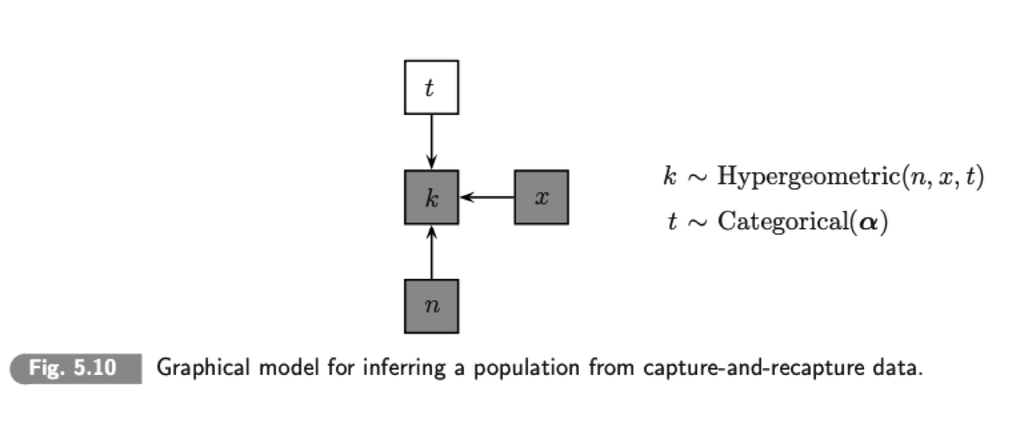

# 2 Estimation

[Binomial coefficient](https://en.wikipedia.org/wiki/Binomial_coefficient)는 `logfact`로 구현할 수 있다. 가령,
$$\binom{n}{k} = \frac{n!}{k!(n-k)!}$$
은 `logfact(n) - logfact(k) - logfact(n-k)`로 구현된다.

교재에서 제공된 [코드](https://bayesmodels.com/)에서 `Planes.txt`의 모델은 오류가 난다. 아래는 `PlanesJ.txt` 파일의 모델을 수정하였다.

```r
x <- 10 # number of captures
k <- 4  # number of recaptures from n
n <- 5  # size of second sample
tmax <- 50 # maximum population size
zeros <- 0 # for zeros trick

data <- list("x","k","n","tmax","zeros")

# Planes
mymodel <- function() {
  # Hypergeometric Likelihood Via Zeros Trick
  logterm1 <- logfact(x+.01)-logfact(k+.01)-logfact(x-k+.01)
  logterm2 <- logfact(t-x+.01)-logfact(n-k+.01)-logfact((t-x)-(n-k)+.01)
  logterm3 <- logfact(t+.01)-logfact(n+.01)-logfact(t-n+.01)
  C <- 1000
  phi <- -(logterm1+logterm2-logterm3)+C
  zeros ~ dpois(phi)
  # Prior on Population Size
  for (i in 1:tmax){
    tptmp[i] <- step(i-(x+n-k))
    tp[i] <- tptmp[i]/sum(tptmp[1:tmax])
  }
  t ~ dcat(tp[])
  }

samples <- jags(data = data,
                parameters.to.save = c("t"),
                inits = list(list(t = 25)),
                model.file = mymodel,
                n.chains = 1, n.iter = 10000, n.burnin = 1, n.thin = 1,
                jags.module = c("dic")
)
print(samples)
```

```
## Inference for Bugs model at "/var/folders/q0/7hh9cyp12fl453gbm_1gft200000gn/T//RtmpmGvJMB/model6245399fd6c3.txt", fit using jags,
##  1 chains, each with 10000 iterations (first 1 discarded)
##  n.sims = 9999 iterations saved
##           mu.vect sd.vect     2.5%      25%    50%      75%    97.5%
## t          17.100   6.662   11.000   13.000   15.0   19.000   37.000
## deviance 2002.915   2.006 2001.264 2001.426 2002.1 2003.632 2008.682
##
## DIC info (using the rule, pD = var(deviance)/2)
## pD = 2.0 and DIC = 2004.9
## DIC is an estimate of expected predictive error (lower deviance is better).
```

# 3 Visualization

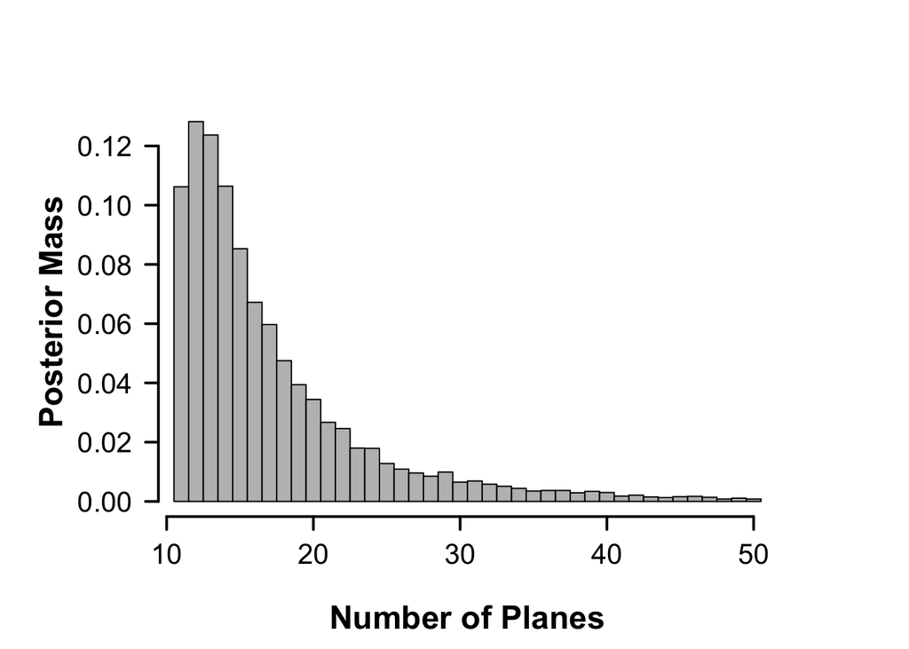

```r
t <- samples$BUGSoutput$sims.list$t

# Plot the posterior for theta:
# windows(width=9,height=6) #Works only under Windows
par(cex.main = 1.5, mar = c(5, 6, 4, 5) + 0.1, mgp = c(3.5, 1, 0), cex.lab = 1.5,
    font.lab = 2, cex.axis = 1.3, bty = "n", las=1)
hist(t, xlim=c(x+n-k,tmax), lty=1, lwd=2, col="grey", prob=T, breaks=(((x+n-k-1):tmax)+.5),
     axes=T, main=" ", xlab="Number of Planes", ylab="Posterior Mass")
```

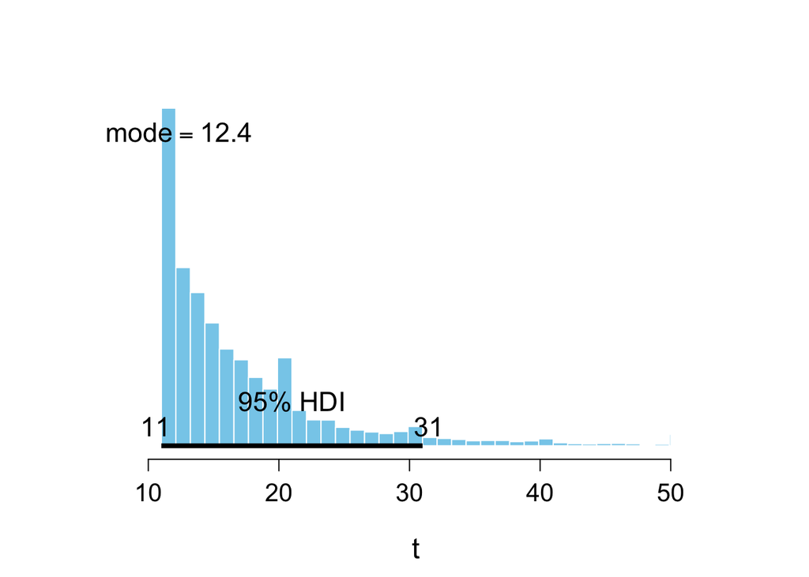

```r
p <- posterior(samples)
# headTail(p)
plot_post(p$t, xlab = expression(t), quietly = TRUE)
```

# 4 Exercise 5.6.1

$k = 4$에서 $k = 0$로 바꾸면,

```r
k <- 0  # number of recaptures from n
tmax <- 50 # maximum population size
samples2 <- jags(data = data,
                 parameters.to.save = c("t"),
                 inits = list(list(t = 25)),
                 model.file = mymodel,
                 n.chains = 1, n.iter = 10000, n.burnin = 1, n.thin = 1,
                 jags.module = c("dic")
)
```

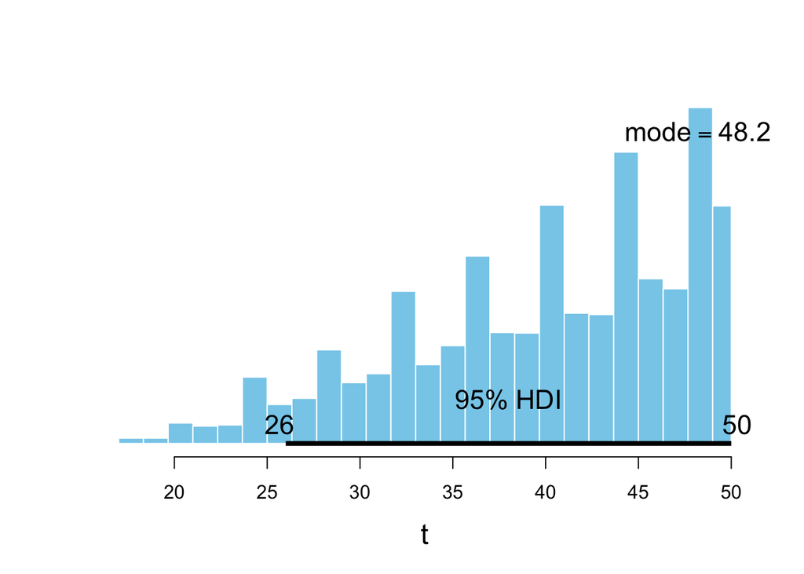

```r
# print(samples2)
plot_post(posterior(samples2)$t, xlab = expression(t), quietly = TRUE)
```

# 5 Exercise 5.6.2

$t^{max} = 50$에서 $t^{max} = 100$으로 바꾸면, $k = 4$일 때;

```r
k <- 4  # number of recaptures from n
tmax <- 100 # maximum population size
samples3 <- jags(data = data,
                 parameters.to.save = c("t"),
                 inits = list(list(t = 25)),
                 model.file = mymodel,
                 n.chains = 1, n.iter = 10000, n.burnin = 1, n.thin = 1,
                 jags.module = c("dic")
)
```

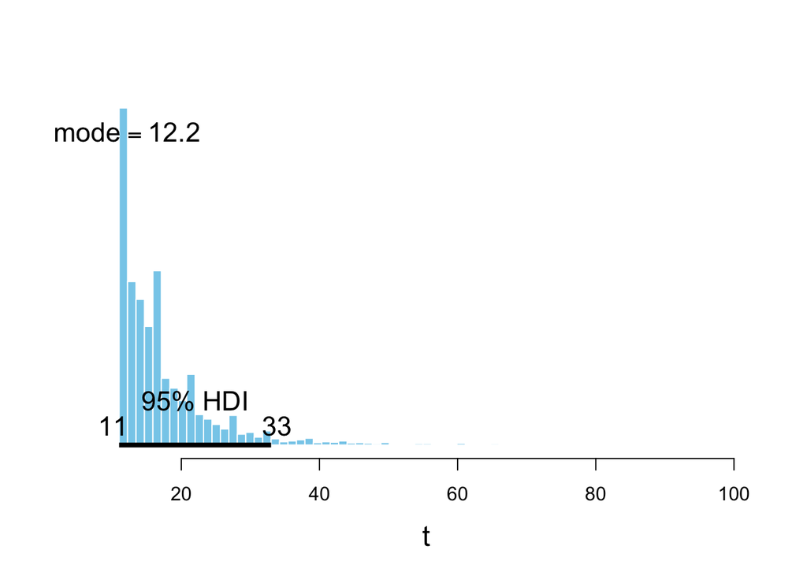

```r
# print(samples3)
plot_post(posterior(samples3)$t, xlab = expression(t), quietly = TRUE)
```

$k = 0$일 때;

```r
k <- 0  # number of recaptures from n
tmax <- 100 # maximum population size
samples4 <- jags(data = data,
                 parameters.to.save = c("t"),
                 inits = list(list(t = 25)),
                 model.file = mymodel,
                 n.chains = 1, n.iter = 10000, n.burnin = 1, n.thin = 1,
                 jags.module = c("dic")
)
```

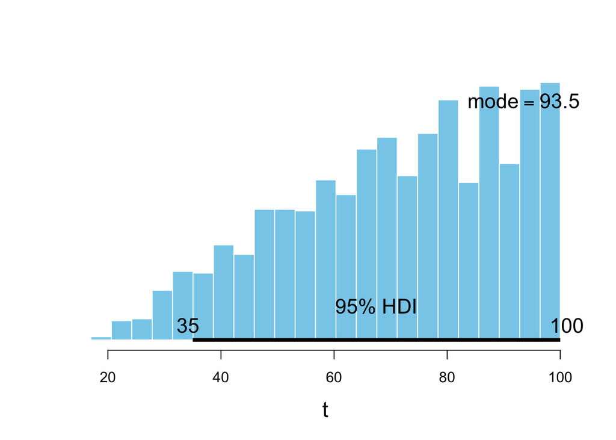

```r
# print(samples4)
plot_post(posterior(samples4)$t, xlab = expression(t), quietly = TRUE)
```

# 6 Session Info

```r
sessionInfo()
## R version 4.3.3 (2024-02-29)
## Platform: aarch64-apple-darwin20 (64-bit)
## Running under: macOS Sonoma 14.4
##
## Matrix products: default
## BLAS:   /Library/Frameworks/R.framework/Versions/4.3-arm64/Resources/lib/libRblas.0.dylib
## LAPACK: /Library/Frameworks/R.framework/Versions/4.3-arm64/Resources/lib/libRlapack.dylib;  LAPACK version 3.11.0
##
## locale:
## [1] en_US.UTF-8/en_US.UTF-8/en_US.UTF-8/C/en_US.UTF-8/en_US.UTF-8
##
## time zone: Asia/Seoul
## tzcode source: internal
##
## attached base packages:
## [1] stats     graphics  grDevices utils     datasets  methods   base
##
## other attached packages:
##  [1] CalvinBayes_0.2.6 bayesplot_1.11.1  ggformula_0.12.0  ggridges_0.5.6
##  [5] scales_1.3.0      ggplot2_3.5.0     dplyr_1.1.4       klippy_0.0.0.9500
##  [9] R2jags_0.7-1.1    rjags_4-15        coda_0.19-4.1     cowplot_1.1.3
## [13] pacman_0.5.1
##
## loaded via a namespace (and not attached):
##   [1] ggdag_0.2.12         gridExtra_2.3        inline_0.3.19
##   [4] sandwich_3.1-0       rlang_1.1.3          magrittr_2.0.3
##   [7] multcomp_1.4-25      matrixStats_1.2.0    compiler_4.3.3
##  [10] loo_2.7.0            vctrs_0.6.5          reshape2_1.4.4
##  [13] stringr_1.5.1        pkgconfig_2.0.3      fastmap_1.1.1
##  [16] magick_2.8.3         backports_1.4.1      ellipsis_0.3.2
##  [19] utf8_1.2.4           threejs_0.3.3        promises_1.2.1
##  [22] rmarkdown_2.26       markdown_1.12        haven_2.5.4
##  [25] R2WinBUGS_2.1-22.1   purrr_1.0.2          xfun_0.42
##  [28] cachem_1.0.8         labelled_2.12.0      jsonlite_1.8.8
##  [31] highr_0.10           later_1.3.2          broom_1.0.5
##  [34] parallel_4.3.3       R6_2.5.1             dygraphs_1.1.1.6
##  [37] StanHeaders_2.32.6   bslib_0.6.1          stringi_1.8.3
##  [40] boot_1.3-30          estimability_1.5     jquerylib_0.1.4
##  [43] Rcpp_1.0.12          assertthat_0.2.1     rstan_2.32.6
##  [46] knitr_1.45           zoo_1.8-12           base64enc_0.1-3
##  [49] splines_4.3.3        httpuv_1.6.14        Matrix_1.6-5
##  [52] igraph_2.0.3         tidyselect_1.2.1     rstudioapi_0.15.0
##  [55] abind_1.4-5          yaml_2.3.8           codetools_0.2-19
##  [58] miniUI_0.1.1.1       curl_5.2.1           pkgbuild_1.4.4
##  [61] lattice_0.22-5       tibble_3.2.1         plyr_1.8.9
##  [64] shiny_1.8.0          withr_3.0.0          bridgesampling_1.1-2
##  [67] posterior_1.5.0      evaluate_0.23        survival_3.5-8
##  [70] RcppParallel_5.1.7   xts_0.13.2           pillar_1.9.0
##  [73] tensorA_0.36.2.1     checkmate_2.3.1      DT_0.32
##  [76] stats4_4.3.3         shinyjs_2.1.0        distributional_0.4.0
##  [79] generics_0.1.3       hms_1.1.3            rstantools_2.4.0
##  [82] munsell_0.5.0        gtools_3.9.5         xtable_1.8-4
##  [85] glue_1.7.0           emmeans_1.10.0       tools_4.3.3
##  [88] shinystan_2.6.0      colourpicker_1.3.0   forcats_1.0.0
##  [91] mvtnorm_1.2-4        tidygraph_1.3.1      grid_4.3.3
##  [94] tidyr_1.3.1          QuickJSR_1.1.3       crosstalk_1.2.1
##  [97] colorspace_2.1-0     nlme_3.1-164         cli_3.6.2
## [100] fansi_1.0.6          Brobdingnag_1.2-9    mosaicCore_0.9.4.0
## [103] V8_4.4.2             gtable_0.3.4         sass_0.4.9
## [106] digest_0.6.35        TH.data_1.1-2        brms_2.20.4
## [109] htmlwidgets_1.6.4    htmltools_0.5.7      lifecycle_1.0.4
## [112] mime_0.12            shinythemes_1.2.0    MASS_7.3-60.0.1
```